# STATS 205: Homework Assignment 5

Brian Liu

6/10/2019

## Solution to Problem 1

> We say that two observations $X_1$ and $X_2$ are *independent* of one another with respect to a collection of events $\mathcal{A}$ if

> $$Pr\left\{X_1 \in A \textrm{ and } X_2 \in B\right\} = Pr\left\{X_1 \in A \right\}Pr\left\{X_2 \in B\right\}$$
> where A and B are any two not necessarily distinct sets of outcomes belonging to $\mathcal{A}^3$.

– [2.2.1 Independent Observations; Permutation, Parametric, and Bootstrap Tests of Hypotheses; Good, Phillip I](https://searchworks.stanford.edu/view/12473402)

> In deciding whether your own observations are exchangeable and a permutation test applicable, the key question is the one we posed in the very first chapter: Under the null hypothesis of no differences among the various experimental or survey groups, can we exchange the labels on the observations without significantly affecting the results?

– [2.2.2 Exchangeable Observations; Permutation, Parametric, and Bootstrap Tests of Hypotheses; Good, Phillip I](https://searchworks.stanford.edu/view/12473402)

## Solution to Problem 2

```r
cysticerci <- c(28.9, 32.8, 12.0, 9.9, 15.0, 38.0, 12.5, 36.5, 8.6, 26.8)
worms_reco <- c(1.0, 7.7, 7.3, 7.9, 1.1, 3.5, 18.9, 33.9, 28.6, 25.0)
```

The null hypothesis is that the mean weight of introduced cysticerci *has no correlation with* the mean weight of worms recovered. That is,

$$H_0: \tau = 0$$

The alternative hypothesis is that the mean weight of introduced cysticerci is *positively correlated with* the mean weight of worms recovered. That is,

$$H_A: \tau > 0$$

To test the null hypothesis against the alternative hypothesis, we will use the Kendall test, a distribution-free test for independence based on signs.

```r
cor.test(x = cysticerci, y = worms_reco, method = "kendall", alt = "greater")
```

```
##
##  Kendall's rank correlation tau
##
## data:  cysticerci and worms_reco
## T = 19, p-value = 0.7578
## alternative hypothesis: true tau is greater than 0
## sample estimates:
##        tau
## -0.1555556
```

The $p$-value is $0.7578$, which is *not* significant at the $\alpha = 0.05$ level. There is *not enough* evidence that the mean weight of introduced cysticerci is *positively correlated with* the mean weight of worms recovered.

## Solution to Problem 3

```r
cysticerci <- c(28.9, 32.8, 12.0, 9.9, 15.0, 38.0, 12.5, 36.5, 8.6, 26.8)
worms_reco <- c(1.0, 7.7, 7.3, 7.9, 1.1, 3.5, 18.9, 33.9, 28.6, 25.0)
cor.test(x = cysticerci, y = worms_reco, method = "kendall", alt = "greater")
```

```
##
##  Kendall's rank correlation tau
##
## data:  cysticerci and worms_reco
## T = 19, p-value = 0.7578
## alternative hypothesis: true tau is greater than 0
## sample estimates:
##        tau
## -0.1555556
```

The estimate for $\tau = -0.1555556$.

## Solution to Problem 4

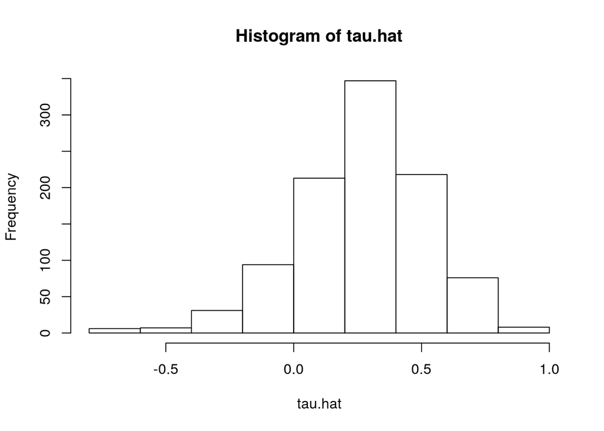

```
##
## 1 - alpha = 0.9 two-sided CI for tau:
## -0.167, 0.66
```

```r
brain_weight = c(515, 286, 469, 410, 461, 436, 479, 198, 389, 262, 536)
fiber_count  = c(32500, 26800, 11410, 14850, 23640, 23820, 29840, 21830, 24650, 22500, 26000)

library(NSM3)
kendall.ci(x=brain_weight, y=fiber_count, alpha = 0.1, type = 't', bootstrap = T, B = 1000)
```

## Solution to Problem 5

```r
cysticerci <- c(28.9, 32.8, 12.0, 9.9, 15.0, 38.0, 12.5, 36.5, 8.6, 26.8)
worms_reco <- c(1.0, 7.7, 7.3, 7.9, 1.1, 3.5, 18.9, 33.9, 28.6, 25.0)
```

The null hypothesis is that the mean weight of introduced cysticerci *has no correlation with* the mean weight of worms recovered. That is,

$$H_0: r_s < r_{s,\alpha}$$

The alternative hypothesis is that the mean weight of introduced cysticerci is *positively correlated with* the mean weight of worms recovered. That is,

$$H_A: r_s \geq r_{s,\alpha}$$

Otherwise, do not reject.

To test the null hypothesis against the alternative hypothesis, we will use the Spearman test, a distribution-free test for independence based on ranks.

```r
# this method of performing the test was given in the textbook, but may not be done correctly here
# hence, I eventually end up performing the same function as on the slides
library(SuppDists)
qSpearman(p = 0.05, r = 10)
```

```
## [1] -0.5393939
```

Since $r_{s,\alpha} = -0.5393939$, we will reject the null hypothesis only if $r_s \geq -0.5393939$.

Calculating $r_s$,

```r
cor(x = cysticerci, y = worms_reco, method = "spearman")
```

```
## [1] -0.2
```

**NOTE**: At this point, I tried to use `cor.test()` with `method = "spearman"` but I got a different result than I expected, and I’m not sure why. Maybe I’m interpreting the output incorrectly?

As shown on the slides,

```r
cor.test(x = cysticerci, y = worms_reco, method = "spearman", alternative = "greater")
```

```
##
##  Spearman's rank correlation rho
##
## data:  cysticerci and worms_reco
## S = 198, p-value = 0.72
## alternative hypothesis: true rho is greater than 0
## sample estimates:
##  rho
## -0.2
```

The $p$-value is $0.72$, which is *not* significant at the $\alpha = 0.05$ level. There is *not enough* evidence that the mean weight of introduced cysticerci is *positively correlated with* the mean weight of worms recovered.

## Solution to Problem 6

```r
x = c(0, 5000, 10000, 15000, 20000, 25000, 30000, 100000)
y = c(0.924, 0.988, 0.992, 1.118, 1.133, 1.145, 1.157, 1.357)
```

$$H_0: \beta = \beta_{0}$$
$$H_0: \beta = 0$$

$$H_A: \beta > \beta_{0}$$
$$H_A: \beta > 0$$

To test the null hypothesis against the alternative hypothesis, we will use the Theil test, a distribution-free test for the slope of the regression line.

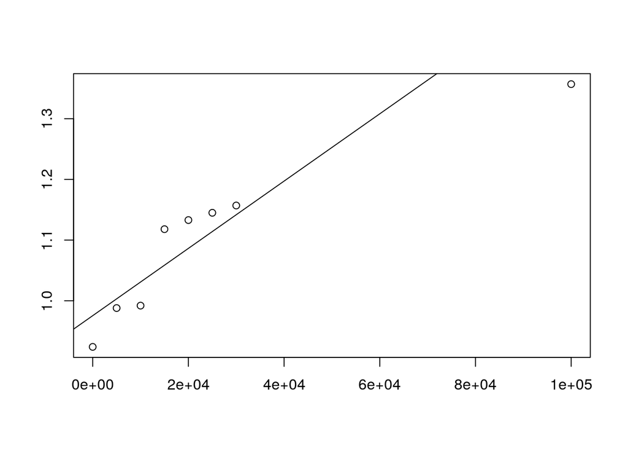

```
## Alternative: beta greater than 0
## C = 28, C.bar = 1, P = 0
## beta.hat = 0
## alpha.hat = 0.975
##
## 1 - alpha = 0.95 upper bound for beta:
## -Inf, 0
```

```r
library(NSM3)
theil(x, y, alpha=0.05, beta.0=0, type = "u")
```

```r
theil.fit = theil (x,
  y,
  beta.0 = 0 ,
  slopes=TRUE,
  type = "u",
  doplot = FALSE)
theil.fit
```

```
## Alternative: beta greater than 0
## C = 28, C.bar = 1, P = 0
## beta.hat = 0
## alpha.hat = 0.975
##
## All slopes:
##  i j         S.ij
##  1 2 1.280000e-05
##  1 3 6.800000e-06
##  1 4 1.293333e-05
##  1 5 1.045000e-05
##  1 6 8.840000e-06
##  1 7 7.766667e-06
##  1 8 4.330000e-06
##  2 3 8.000000e-07
```

[output cut: 24 more lines]

```r
theil.output = theil(x,
  y,
  beta.0 = 0,
  slopes=TRUE,
  type = "u", doplot = FALSE, alpha = .05)
c(theil.output$L, theil.output$U)
```

```
## [1] -Inf    0
```

**TODO**: Interpret these results correctly.

## Solution to Problem 7

```r
height = c(42.8, 63.5, 37.5, 39.5, 45.5, 38.5, 43.0, 22.5, 37.0, 23.5, 33.0, 58.0)
weight = c(40.0, 93.5, 35.5, 30.0, 52.0, 17.0, 38.5, 8.5, 33.0, 9.5, 21.0, 79.0)
heart_catheter_length = c(37.0, 49.5, 34.5, 36.0, 43.0, 28.0, 37.0, 20.0, 33.5, 30.5, 38.5, 47.0)

cor.test(x = height, y = heart_catheter_length, method = "pearson")
```

```
##
##  Pearson's product-moment correlation
##
## data:  height and heart_catheter_length
## t = 5.8936, df = 10, p-value = 0.0001524
## alternative hypothesis: true correlation is not equal to 0
## 95 percent confidence interval:
##  0.6216270 0.9663721
## sample estimates:
##       cor
## 0.8811691
```

```r
cor.test(x = weight, y = heart_catheter_length, method = "pearson")
```

```
##
##  Pearson's product-moment correlation
##
## data:  weight and heart_catheter_length
## t = 6.3033, df = 10, p-value = 8.871e-05
## alternative hypothesis: true correlation is not equal to 0
## 95 percent confidence interval:
##  0.6568763 0.9700971
## sample estimates:
##       cor
## 0.8938226
```

From the Pearson correlation tests, there is *strong evidence* that, individually, height and weight contribute to the determination of heart catheter length.

```r
library(Rfit)

r.01 <- rfit(heart_catheter_length ~ height)
f.01 <- rfit(heart_catheter_length ~ height + weight)
first_drop_test <- drop.test(f.01, r.01)
first_drop_test
```

```
##
## Drop in Dispersion Test
## F-Statistic     p-value
##     1.55202     0.24429
```

```r
r.02 <- rfit(heart_catheter_length ~ weight)
second_drop_test <- drop.test(f.01, r.02)
second_drop_test
```

```
##
## Drop in Dispersion Test
## F-Statistic     p-value
##    0.014435    0.907007
```

However, based on the large p-values from the Drop in Dispersion tests, there is *not enough evidence* to suggest that height or weight contribute significantly over each other to the determination of heart catheter length.

### Note

From the textbook problem,

> Treating length of heart catheter as the *independent* variable, test for the importance of height and weight in *determining* the required catheter length.

If height and weight are the *determiners* of length of heart catheter, length of heart catheter must be the *dependent* variable.